# R Notebook

## Data Story on song lyrics

Music is a great tool to tell story and express feelings we can’t grasp. And music in different genres tend to convey emotion in different ways. Although the genres classifications may be subjective and even overlap, there are still some shared characteristics represented in lyrics through genre breakdown.

### the distribution of each genres

```
##
##              age1970s age1980s age1990s age2000s age2010s    Sum
##   Country          49       20      219     5690     1556   7534
##   Electronic        9       14       44     1843      902   2812
##   Folk             10        0       27      357      120    514
##   Hip-Hop           0       11      254     6268     2370   8903
##   Indie             0        0        0      591      727   1318
##   Jazz             80       92      186     2522     1242   4122
##   Metal             0       63      184     9030     2034  11311
##   Other             5       13        5        4      120    147
##   Pop             163      210      478    12543     5303  18697
##   R&B              65       67      179     1376      487   2174
##   Rock            778      678     2646    50511    10231  64844
##   Sum            1159     1168     4222    90735    25092 122376
```

According to the list, we can see the popularity of different music genres in different phases. Musicians have long-term preferences on Rock music, Pop music, and Country music, besides, Mental and Hip-hop have led a trend after 2000. folk music and Indie music seems to be the niche genre with the fewest audience.

### Word Analysis

Does patterns varies in song lyrics between genres and time? I try to compare the most frequently used words in different genres to get an answer. I take the 6 most popular genre—Country, Hiphop, Jazz, Mental, Pop, and Rock music— as examples, and roughly divide the time into 2 stages of before/after 2010.

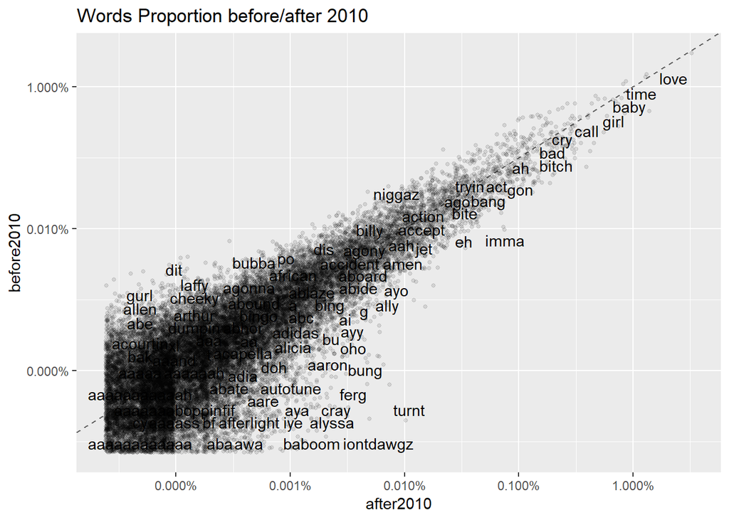

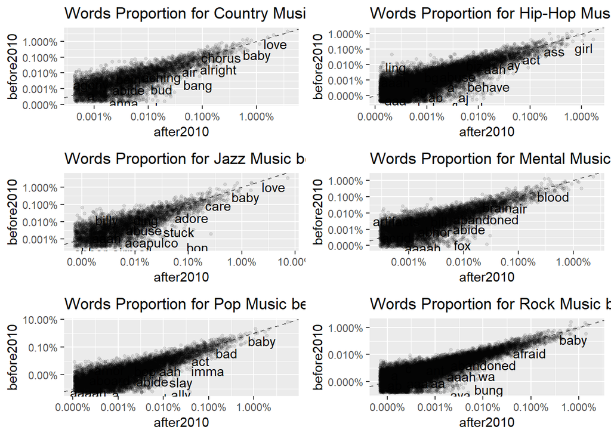

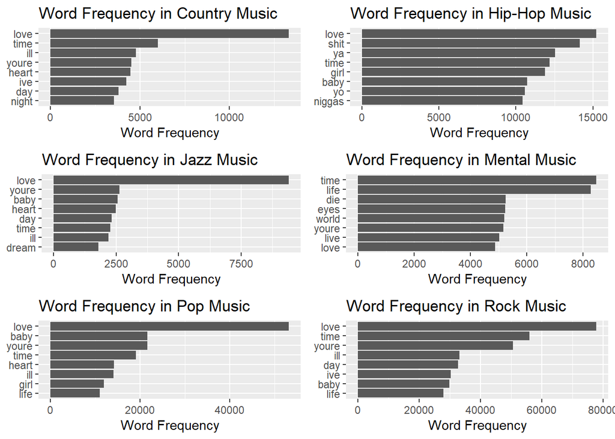

```
## [1] 122376
```

```
## [1] 51182
```

I also list the top 8 frequently used word in every genres, which shows the similar results. among all the 122,376 lines of lyrics, 51182 of which have “love” included. The word “love” show the core emotion from old times to today in every genres, except the mental music which is presented below. Mental music tend to focus on the singers’ inner world rather than the external emotional connections.

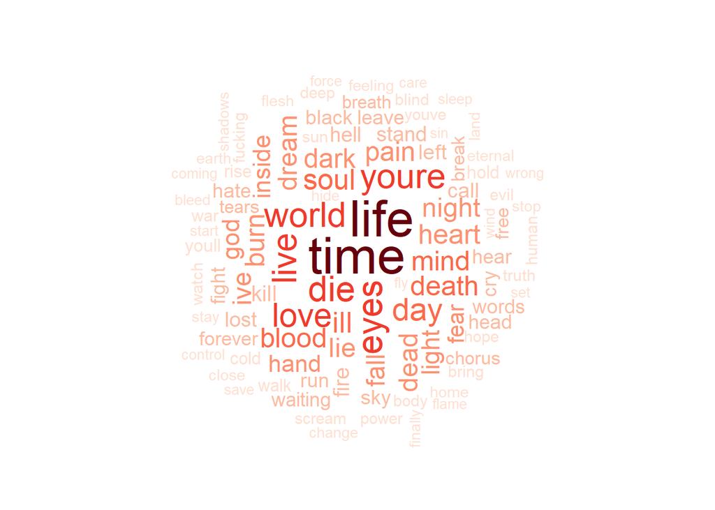

However, love in different genres of music can be different from each others. I compare the word often used in the subset of data which includes “love”,“heart”,“baby”,“youre”

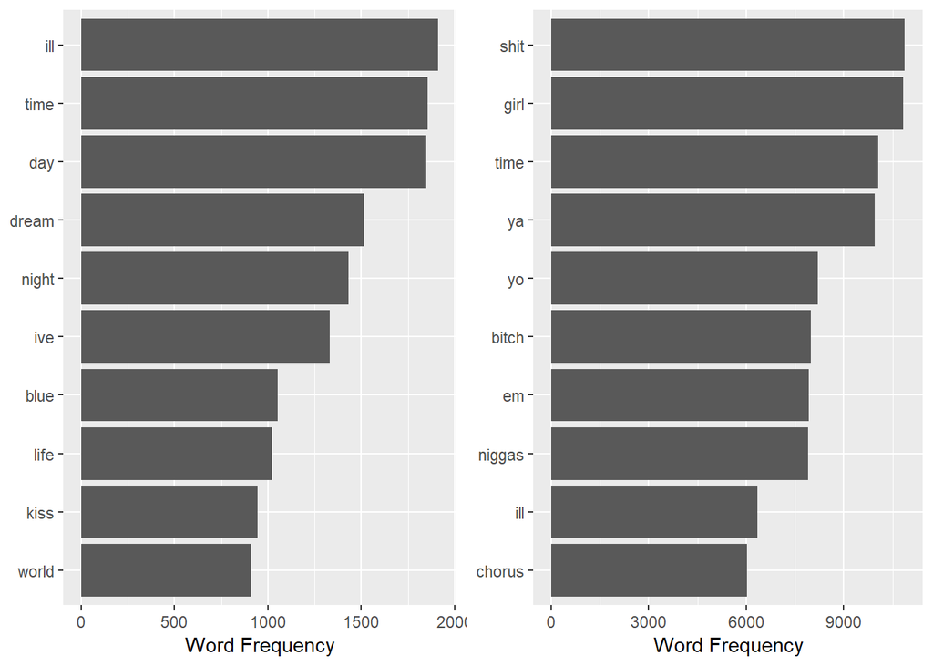

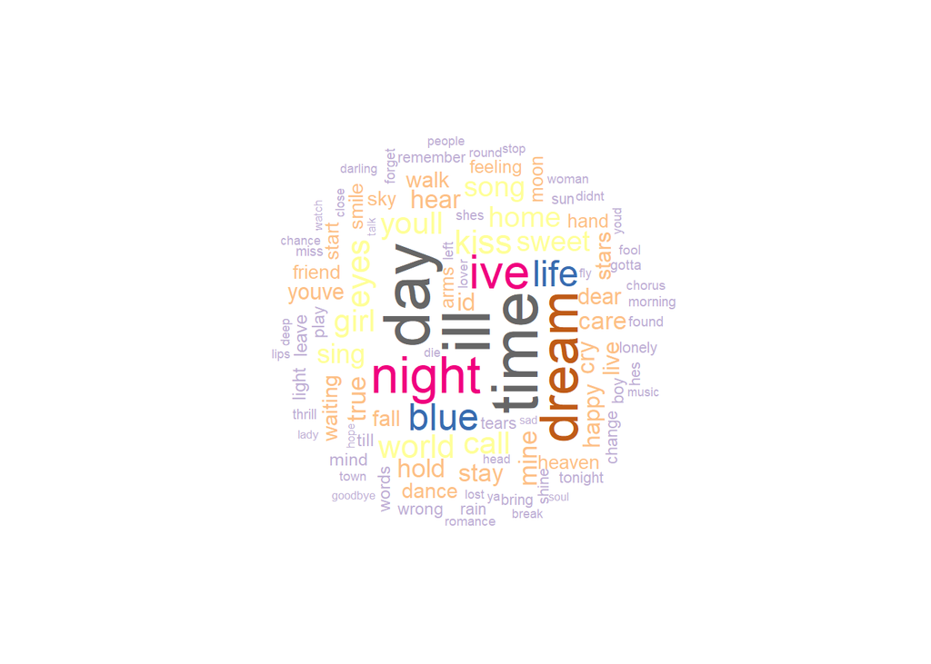

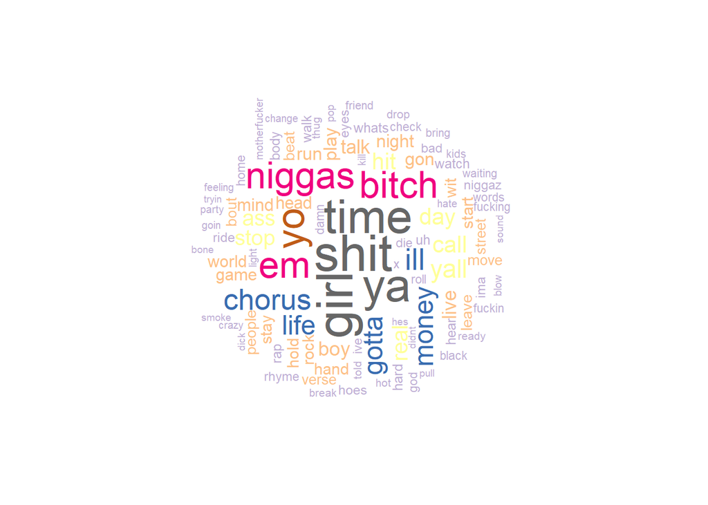

From the results above, I can see jazz and hiphop music have clear difference in word choose. To express love, Jazz musicians prefer more elegant vocabulary like “dream”,“blue”,“night”, while rappers prefers more colloquial and unrefined words.

### Sentiment Analysis

I would also like to examine which genre is the most positive or negative overall?

| word | n |
| --- | --- |
| love | 187198 |
| time | 110131 |
| youre | 98054 |
| baby | 75341 |
| ill | 69885 |
| day | 63758 |
| life | 61115 |
| heart | 56928 |
| ive | 55756 |
| night | 53332 |

[output cut: 9990 more lines]

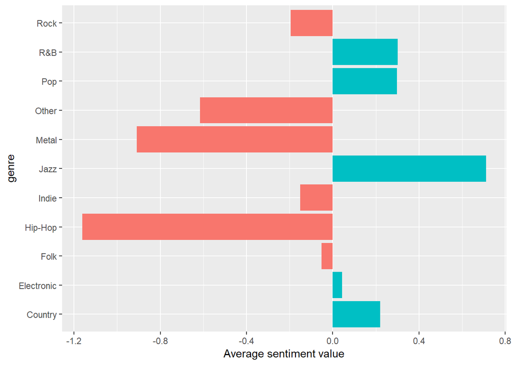

From the plot above, we can see the lyrics in Jazz music deliver the most positive values, and Hip-Hop music contains the most negative messages. These are corresponding to our findings in the word choice to express love.

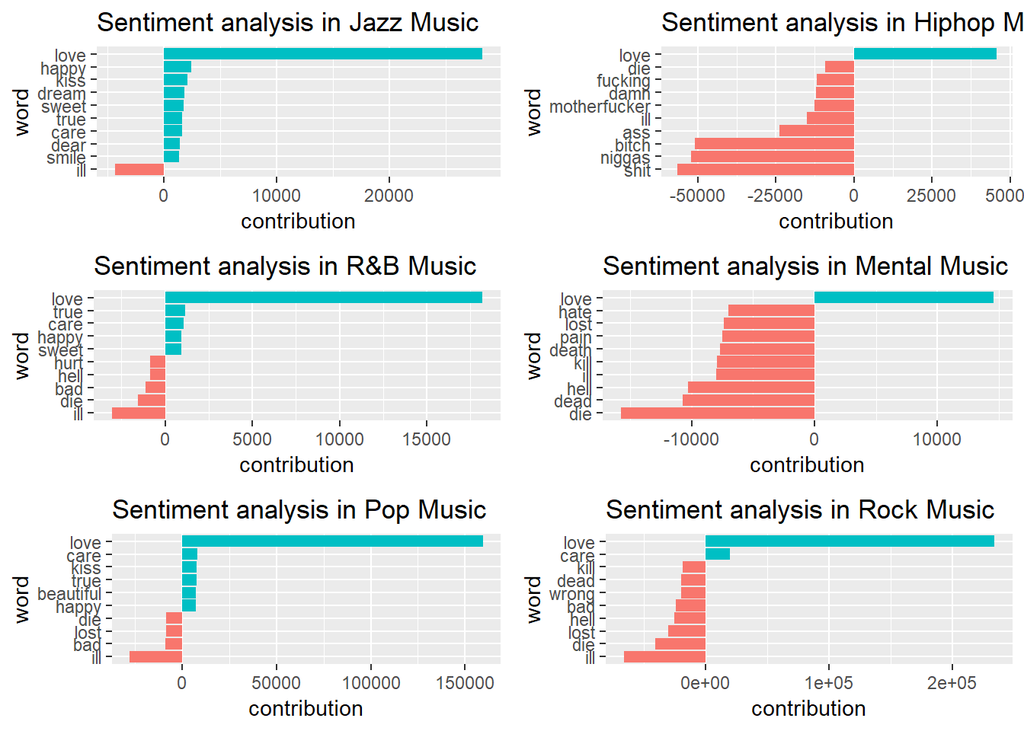

I take 6 different music genres, which are strongly affected by emotion, as examples, and look deeper to analyze which words contributed most to the positive and negative sentiment values. it turns out to be , jazz, R&B, and Pop music on the left contains frequent usage of “love”,“happy”,“true”,“care”, which are quite reasonable to be positive drivers. however, Hip-Hop, Mental, and Rock music mentions a lot about“ill”,“shit”,“die”,“hell” as the the strongest contributors to be negative lyrics.

| genre | artist | sentiment | words |
| --- | --- | --- | --- |
| Country | dolly-parton | 0.46835916 | 10714 |
| Pop | bee-gees | 0.40435459 | 9002 |
| Rock | elton-john | 0.07834702 | 7671 |
| Rock | bob-dylan | -0.28251507 | 8127 |
| Hip-Hop | chris-brown | -0.39434599 | 13937 |
| Hip-Hop | chamillionaire | -0.74288039 | 9832 |
| Hip-Hop | eminem | -1.56748237 | 25377 |
| Hip-Hop | bone-thugs-n-harmony | -1.62518315 | 10920 |
| Hip-Hop | busta-rhymes | -1.78863454 | 11227 |
| Hip-Hop | dmx | -1.94753056 | 10063 |

## Conclusions

1. Song lyrics changes with time, but “love” is the core emotion from past to present
2. Different genres of music have different patterns and word choice to express feelings.
3. Jazz music delivers the most positive messages and Hip-hop music delivers the most negative.